# Vaccine safety surveillance

Tuomo Nieminen 2017

## Table of contents

1. Introduction to safety surveillance
2. Study designs
3. Decision rules
4. Methods (B-maxSPRT)
5. Application of B-maxSPRT to Finnish register data

## Introduction to safety surveillance

Identifying, refining and confirming information

### Drug safety

An adverse event is an untoward medical occurrence in a patient administered a pharmaceutical product.

- Rare adverse events related to drugs are often impossible to detect in pre-licensure studies
- Therefore there is an incentive to monitor the safety of a drug post-licensure
- This monitoring is called safety surveillance

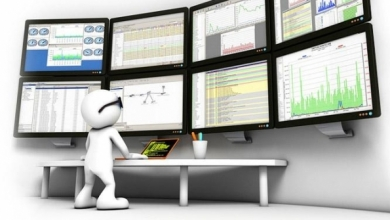

### Stages of safety surveillance

The information related to a possible causal relationship between a drug and an adverse event is called a safety signal (signal).

Post-licensure safety aims related to drugs can be classified into three stages (Nelson 2015):

1. **Signal identification**: Involves detecting unexpected adverse events and considers a large number of events
2. **Signal refinement**: Attempts to address a few specified hypothesis about suspected product-event pairs based on biological plausibility
3. **Signal confirmation**: Involves a more in depth follow-up of a generated signal

### The type of surveillance

A safety surveillance method is a combination of data collection, study design and decision rules for generating signals.

- In this presentation, the medical product of interest is a vaccine product
- I will consider situations where accumulating (register) data can be used and near real-time surveillance is possible
- I will focus on the signal refinement stage and assume that a biologically plausible exposure-event pair is already identified
- I will present possible epidemiological study designs and a powerful statistical hypothesis testing method to derive decision rules for signal generation

### Goals related to safety surveillance

Natural goals related to safety surveillance are to:

- control the expected rate of false positive and false negative signals
- generate a signal as soon as possible, if an association between the vaccine and the adverse event exists.

Usually more samples (longer surveillance) leads to fever errors (higher power)…

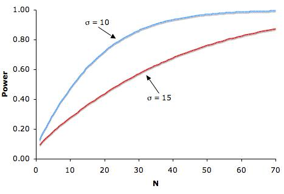

### How to achieve the goals?

**Study design**  
Utilizing a case-only (self-controlled) study designs can help to avoid biases and improve control over the error rates.

**Decision rules**  
Sequential hypothesis testing can achieve the goal of minimizing the expected sample size for given error rates.

**Methods**  
The maxSPRT is a sequential hypothesis testing method designed for vaccine safety surveillance. B-maxSPRT is based on a self-controlled study design.

## Study designs

Avoid a biased sample

### Options

The following study designs could be considered for safety surveillance:

1. **Cohort design**: Groups of exposed and non-exposed individuals are followed forward in time. Incidences of events are compared between the groups.
2. **Case-control design**: Individuals with events are matched to individuals without events. Proportions of exposure are compared between the matches.
3. **Case-only designs**: Individuals with events are self-matched using risk and nonrisk intervals to define cases and controls.

The major weakness of the cohort and case-control designs is that confounders can affect the probability of exposure and result in bias.

### The study design matters

Recent vaccine safety surveillance efforts have generated multiple false positive signals (signals that could not be confirmed), due to:

1. **changes in diagnosis coding**
2. **inappropriate control groups**
3. **uncertainty or changes in baseline incidence**
4. **Type I errors**.

Reason 4 relates to the statistical method used. Reasons 1-3 relate to the study design and they can in theory be avoided with a case-only design.

### Case-only designs: an example

The Self-controlled case series (SCCS) is an example of a case-only design.

- In SCCS, individuals with both vaccinations ad events during an observation period are considered.
- The goal is to compare event incidences during defined risk and control periods.

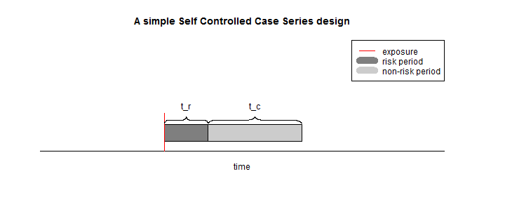

### Case-only designs

The risk of bias is minimal in a case-only design because each case acts as their own control (self-controlled design).

- However, possible time varying confounders must be explicitly accounted for
- The selection of proper risk and control intervals is crucial
- The case-only designs retain relatively high power despite using little data (usually only cases)
- The two most popular case-only designs are the case-crossover design (CCO) and the self-controlled case series design (SCCS)

### Simple SCCS (1)

In SCCS, events for each individual \( i \) are assumed to arrive as a Poisson process during risk (\( r \)) and control (\( c \)) periods.

\[ K_c \sim Poisson(\lambda_{i} \cdot t_c) \quad K_r \sim Poisson(RR_i \cdot \lambda_{i} \cdot t_r) \]

- \( RR_i \) denotes the rate ratio: the multiplicative change in rate during the risk period compared to the control period
- \( t \) denotes the lengths of the periods, with \( t_c / t_r = z \).
- \( \lambda_i \) is the baseline incidence rate for the individual
- Events that occur during the risk period are labeled as “cases” and events during the control period as “controls”

### Simple SCCS (2)

Assuming a homogeneous rate ratio \( RR = RR_i \), the total number of cases conditioned on the total number of events follows a binomial distribution.

\[ K_r = \sum_{i=1}^{n} K_{i, r} \quad N = \sum_{i=1}^n N_{i} \]

\[ P(K_r = k_r \mid N = n) \sim Bin(n, \frac{RR}{z + RR}) \]

The rate ratio parameter \( RR \) is the only unkown parameter. This is typical for the self-controlled designs: The **individual incidences cancel out** from the statistical model.

### Study design conclusions

Ultimately all epidemiological study designs share the same goal: compare some group of individuals to another group of individuals

- In cohort and case-control designs the case and control groups might not be comparable due to confounding
- In self-controlled designs the assignment to the case or control group depends only on the time of the event (or exposure)
- Self-controlled designs implicitly control for all time-invariant confounders.
- Therefore using a self-controlled design can help to control error rates in safety surveillance

## Decision rules

Minimize the expected sample size

### Restating the goals of surveillance

Electronic health care records provide an opportunity to monitor possible problems related to vaccinations in near real time.

- When an association between some exposure and event pair exists, the goal of a safety surveillance method is to generate a safety signal as soon as possible.
- In more statistical terms, the problem is to **minimize the expected sample size until signal generation**, for some fixed rates of false positive and false negative signals.
- This goal can be achieved by using **sequential hypothesis testing** to derive decision rules.

### Hypothesis testing

Statistical inference is based on a probability model \( P(X \mid \theta) \) for the observations \( X \), under some parameters \( \theta \).

- A hypothesis is a proposition which assigns restrictions for the parameter \( \theta \)

\[ H_0 : \theta \in \Theta_0 \quad H_1 : \theta \in \Theta_1. \]

- A test statistic such as the likelihood ratio can be used to derive a decision rule to choose one hypothesis over the other

\[ LR = \frac{P(X \mid H_1 )}{P(X \mid H_0 )}. \]

### General terms and definitions

Some terminology related to hypothesis testing

| Term | Description |
| --- | --- |
| \( H_0 \) | The null hypothesis ( \( H_0 : \theta \in \Theta_0 \) ) |
| \( H_1 \) | The alternative hypothesis ( \( H_1 : \theta \in \Theta_1 \) ) |
| Simple hypothesis | A hypothesis which adresses a single point in the parameter space. (e.g. \( H_0 : \theta = 1 \)) |
| Composite hypothesis | A hypothesis which adresses more than a single point in the parameter space. (e.g. \( H_1: \theta > 1 \)) |
| \( \alpha \) | The type I error probability (false positive rate): \( P(\text{reject } H_0 \mid H_0) \). |
| \( \beta \) | The type II error probability (false negative rate): \( P(\text{accept } H_0 \mid H_1) \). |
| \( Power \) | \( 1 - \beta \) |

### A sequential hypothesis test

A procedure called the sequential probability ratio test (**SPRT**) minimizes the expected sample size when testing two simple hypothesis.

- SPRT is a **sequential hypothesis test**.

A sequential hypothesis test gives a rule of making one of three possible decisions at a single trial of the experiment:

1. **Accept** \( H_0 \)
2. **Reject** \( H_0 \)
3. **Continue** the experiment by making an additional observation.

### SPRT (1)

SPRT is the **most powerfull** sequential test for testing two simple hypothesis.

- SPRT reduces the expected sample size by ~50% compared to a regular hypothesis test with similar error rates
- SPRT uses the likelihood ratio \( LR \) as the test statistic

\[ LR_n = \frac{P(x_n \mid H_1)}{ P(x_n \mid H_0)} \]

The test statistic is calculated whenever a new observation arrives

### SPRT (2)

At each new observation, the SPRT test statistic is compared to two critical values to make a desicion of accepting or rejecting \( H_0 \).

- When the test statistic exceeds a boundary, the test terminates with a decision.

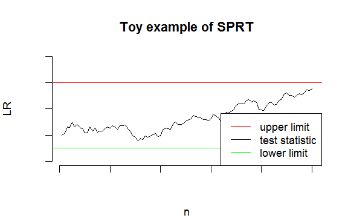

### Setting the hypothesis for safety surveillance

When the objective is to find evidence of an association between an exposure and an event, the null proposition is a state of no association.

- The most natural alternative hypothesis however is composite: some positive association. This can be stated with the rate ratio \( RR \) parameter as follows:
- \( H_0: RR = 1 \)
- \( H_1: RR > 1 \)

In this case an extension of SPRT called the **maxSPRT** can be used to perform sequential hypothesis testing.

### maxSPRT

maxSPRT is a sequential hypothesis test which uses the maximized likelihood ratio as a test statistic.

\[ LR_n = \underset{RR > 1}{max} \frac{P( x_n \mid RR)}{P( x_n \mid RR = 1)} \]

- maxSPRT uses **one critical value \( c \)**: if at any point \( LR_n \geq c \), then \( H_0 \) is rejected
- maxSPRT uses an **upper boundary N** on the sample size: if \( n > N \), then \( H_0 \) is accepted.

### maxSPRT as an algorithm

1. Choose a desired type I error rate \( \alpha \) an upper boundary for the sample size \( N \).
2. Compute the critical value of the test \( c \).
3. After observation \( n = 1, .., N - 1 \) do
   - if \( LR_n \geq c \) stop, reject \( H_0 \)
   - otherwise continue
4. After observation \( N \) do
   - if \( LR_N \geq c \) stop, reject \( H_0 \)
   - otherwise reject \( H_1 \) (accept \( H_0 \))

### Sequential testing: conclusions

SPRT type sequential testing is only suitable if **new data is available often enough** because it assumes that the test can terminate at every new observation.

- The performance of sequential tests is optimized when all available data is utilized as frequently as possible
- Sequential testing can reduce the expected sample size by ~50% compared to regular hypothesis tests with similar error rates
- The chosen upper limit \( N \) in maxSPRT affects the power and the critical value of the test (higher \( N \) -> higher power and higher \( c \))

## Methods (B-maxSPRT)

Combining a study design and decision rules

### Self-controlled maxSPRT

By combining a self-controlled design such as the SCCS and a maxSPRT sequential hypothesis test, we get a safety surveillance method called the Binomial maxSPRT (**B-maxSPRT**).

The likelihood ratio test statistic is

\[ LR_n = \underset{RR>1}{max} \frac{ (\frac{RR}{z + RR})^k \cdot (\frac{z}{z + RR})^{n - k} }{ (\frac{1}{z + 1})^k \cdot (\frac{z}{z + 1})^{n - k} }. \]

Maximizing the likelihood ratio is done by finding the maximum likelihood estimate for the parameter \( RR \)

\[ \hat{RR} = max\{1, \frac{z \cdot k}{n - k} \}. \]

### Log-likelihood ratio

For computational reasons, it is conventient to operate with the log likelihood ratio which can equivalently be used as a test statistic.

\[ LLR_n = log(LR_n) = log \left( \frac{ (\frac{\hat{RR}}{z + \hat{RR}})^k \cdot (\frac{z}{z + \hat{RR}})^{n - k} }{ (\frac{1}{z + 1})^k \cdot (\frac{z}{z + 1})^{n - k} } \right). \]

The same maximum likelihood estimator \( \hat{RR} = max\{1, \frac{z \cdot k}{n - k} \} \) applies.

### Critical values of sequential tests

SPRT type tests solve the problem of multiple testing by considering the joint distribution of the test statistic.

\[ P(LR_n \geq c \text{ for some } n = 1, .., N) = \alpha \]

- The critical value \( c \) is computed such that the total probability of generating a false positive signal is some defined \( \alpha \):
- Computing the critical values of the test requires further research for most statistical models
- For the binomial and Poisson models a solution exists.

### The critical values of B-maxSPRT

A Markov chain approach can be applied to find the critical values in the binomial case of maxSPRT.

- The sequential test procedure can be thought of as transitions from state \( s_{n} \) to state \( s_{n+1} \), starting from the state \( s_0 = (0,0) \) with probability 1.
- The state space \( S \) is the combinations of all possible values for number of events \( n \) and cases \( k \)

\[ S = (n, k) , \quad \text{where} \quad n = 0,.., N \quad \text{and} \quad k = 0,..,n. \]

### A Binomial Markov chain

The probability of entering state \( s_{n+1} \) depends only on the current state \( s_n \) (is it absorbing?) and the probability of “success” (event classified as case).

\[ P(S_{n+1} \mid S_n, .., S_1) = P(S_{n+1} \mid S_n) \]

- In maxSPRT, the set of absorbing states in the experiment are the states \( Q \) for which the value of the test statistic exceeds the critical value \( c \)

\[ Q = \{s \in S \mid LLR_n(s) \geq c \} \]

### B-maxSPRT critical

The critical value \( c \) of the B-maxSPRT test can be found iteratively with the following algorithm:

1. Compute all possible test statistic values \( L = \{LLR_n(s) \mid s \in S\} \) and sort \( L \) from lowest to highest.
2. Choose \( c = min\{L\} \) to be the critical value. The absorbing states are \( Q = \{s \in S \mid LLR_n(s) \geq c \} \).
3. Compute \( P(Q \mid H_0) = \pi \)
4. if \( \pi \leq \alpha \), stop, choose \( c \) to be the critical value
5. otherwise remove \( c \) from \( L \) and go to 2.

## Application of B-maxSPRT

exposure: PCV, Rota or MPR vaccination  
event: Fever seizures

### About the experiment

In this application, B-MaxSPRT was retrospectively applied to Finnish register data. We pretend as if we are observing new data daily.

- **Exposure**: PCV, Rota or MPR vaccination
- **Events**: fever seizure related hospitalizations
- It is established that MPR vaccination causes acute fever seizures. This relationship has also been shown using the Finnish register data.
- There is no evidence of PCV or Rota having similar effects

B-maxSPRT was **expected to generate** a signal related to MPR, but not PCV or Rota.

### Data

The vaccinations of interest are the first doses of MPR, PCV and Rota vaccinations for children under 2 years of age born during 2010 - 2014.

- For the MPR group, the 2014 cohort was exluded because the expected age at vaccination is higher and no sufficient data was yet available.
- The possible adverse events of interest are hospitalizations with [icd-10 diagnosis codes related to fever seizures.](https://terho.thl.fi/wiki01/display/rokobiom/Case-series+analyysi)

### ICD-10 codes

The following icd-10 codes were considered:

- **A**. A858 *Other specified viral encephalitis*, A86 *Unspecified viral encephalitis*, A87 *Viral meningitis*, A88 *Other viral infections of central nervous system, not elsewhere classified*
- **G**. G038 *Meningitis due to other specified causes*, G039 *Meningitis, unspecified*, G04 *Encephalitis, myelitis and encephalomyelitis*, G05 *Encephalitis, myelitis and encephalomyelitis in diseases classified elsewhere*
- **R**. R291 *Meningismus*, R55 *Syncope and collapse*, R560 *Febrile convulsions*, R568 *Other and unspecified convulsions*

### Age intervals and observation periods

For both vaccinations and hospitalizations, age intervals that cover first dose vaccinations of the chosen vaccines were considered:

- MPR: 250 - 650 days
- Rota: 30 - 140 days
- PCV: 60 - 200 days

The risk interval was chosen to be **1-14** days after vaccination and control interval **15-42** days after vaccination. This includes an assumption that the possible effect of the vaccination is transient.

### Surveillance conditions (1)

The safety surveillance method used was B-maxSPRT. The parameters \( N \), \( c \) and \( \alpha \) were defined as:

- \( N \): This was taken to be the expected number of events during the retrospective time period (2010-) under \( H_0 \) for each age group, according to an estimated baseline incidence.
- Type I error (false positive) probability was chosen to be \( \alpha = 0.05 \).
- \( c \): Exact critical values were computed using the Sequential R-package

### Surveillance conditions (2)

Below are the parameters which define the stopping conditions of the maxSPRT method for each vaccine group.

|  | N | c | power | alpha |
| --- | --- | --- | --- | --- |
| MPR | 380 | 3.78 | 0.92 | 0.05 |
| ROTA | 258 | 3.69 | 0.80 | 0.05 |
| PCV | 253 | 3.68 | 0.79 | 0.05 |

The power is calculed using an assumed rate ratio of 1.5.

### Surveillance results, MPR

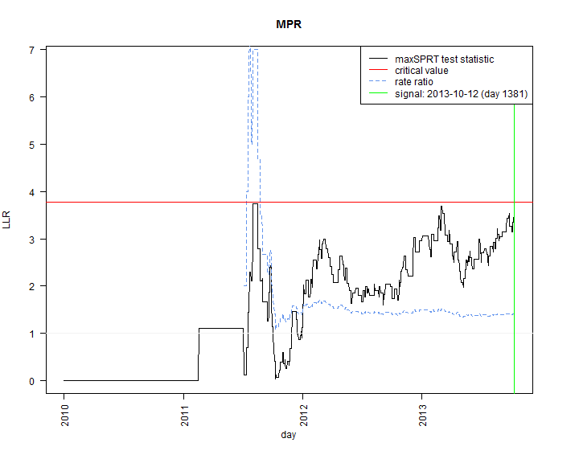

### Surveillance results, Rota

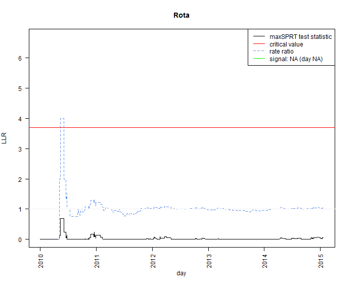

### Surveillance results, PCV

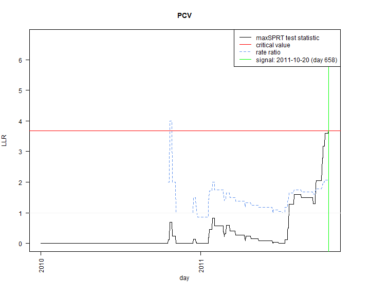

### Surveillance results summary

A signal was generated for MPR and PCV and not generated for Rota.

|  | signal | day | LLR | cases | controls | n | RR |
| --- | --- | --- | --- | --- | --- | --- | --- |
| MPR | TRUE | 1381 | 3.80 | 102 | 142 | 244 | 1.44 |
| Rota | FALSE | 1850 | 0.08 | 89 | 169 | 258 | 1.05 |
| PCV | TRUE | 658 | 3.71 | 29 | 28 | 57 | 2.07 |

Notably the signal generated for PCV came with relatively low \( n \) concidering the number of days passed.

### More surveillance results, MPR

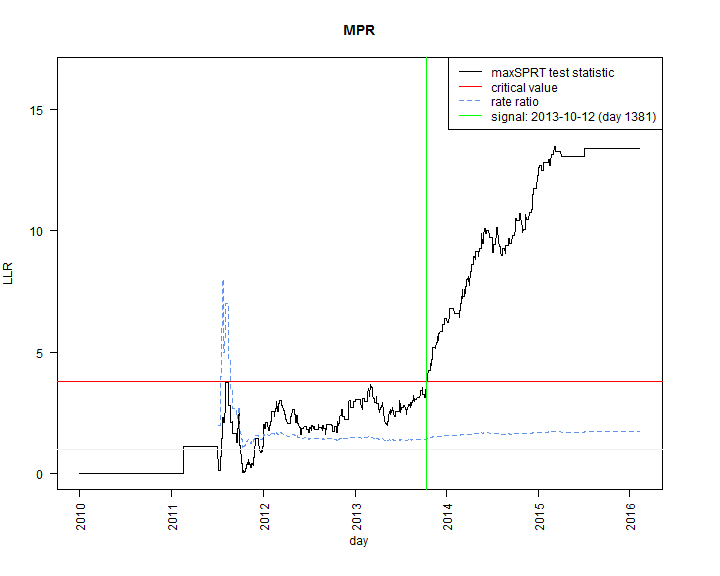

### More surveillance results, PCV

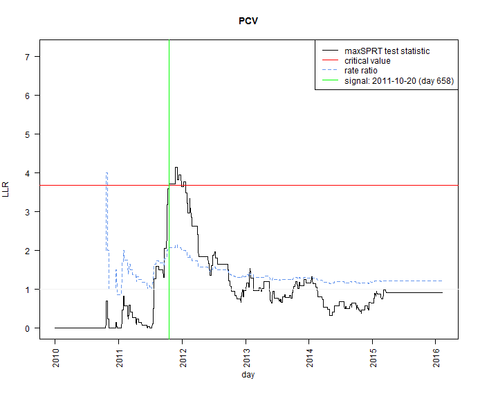

### Surveillance conclusions

The surveillance method generated an expected signal related to MPR, but also an unexpected signal related to PCV

- However, further surveillance showed that when using all the available data, the estimate of the rate ratio for the PCV group was close to 1 (1.22)
- Therefore the signal related to PCV could be a type I error, which were expected to occur 5% of the time for each exposure event pair.

## Thank you!

### Literature

- Jennison (2000): Group Sequential Methods with Applications to Clinical Trials
- Kulldorff (2011): A Maximized Sequential Probability Ratio Test for Drug and Vaccine Safety Surveillance
- Leite (2016): Near Real-time Vaccine Safety Surveillance Using Electronic Health Records - a Systematic Review of the Application of Statistical Methods
- Maclure (1991): The Case-Crossover Design: A Method for Studying Transient Effects on the Risk of Acute Effects
- McClure (2008): Comparison of Epidemiologic Methods for Active Surveillance of Vaccine Safety
- Nelson (2015): Methods for Observational Post-licensure Medical Product Safety Surveillance
- Wald (1945): Sequential Tests of Statistical Hypothesis